# Keehan_Alyssa_HW1

Vertebral Column Data

**Name:** Alyssa Keehan **GitHub Username:** akeehan56  
**Email:** akeehan@usc.edu  
**USC ID:** 3429542433

### (a) Download Data

#### Package imports

```python
# ! pip install scikit-learn
# ! pip install --upgrade scikit-learn
# ! pip install --upgrade pip
#! pip install --upgrade --force-reinstall --no-cache-dir \
#    numpy scipy scikit-learn pandas matplotlib seaborn
```

```python
import numpy as np
import pandas as pd
import matplotlib.pyplot as plt
import seaborn as sns

from sklearn.neighbors import KNeighborsClassifier
from sklearn.metrics import (
    accuracy_score,
    confusion_matrix,
    f1_score,
    precision_score,
    recall_score,
)
```

Get the Vertebral Column Data Set

```python
#initiate the column names at the beginning since they are not available in the raw data
column_names = [
    "pelvic_incidence",
    "pelvic_tilt",
    "lumbar_lordosis_angle",
    "sacral_slope",
    "pelvic_radius",
    "grade_spondylolisthesis",
    "class"
]

data = pd.read_csv(
    "../data/vertebral_column_data/column_2C.dat",
    sep=r"\s+",
    header=None,
    names=column_names
)

data["class"] = data["class"].map({"NO": 0, "AB": 1})

independent_variables = data.columns[:-1].tolist()

data.head()
```

|  | pelvic_incidence | pelvic_tilt | lumbar_lordosis_angle | sacral_slope | pelvic_radius | grade_spondylolisthesis | class |
| --- | --- | --- | --- | --- | --- | --- | --- |
| 0 | 63.03 | 22.55 | 39.61 | 40.48 | 98.67 | -0.25 | 1 |
| 1 | 39.06 | 10.06 | 25.02 | 29.00 | 114.41 | 4.56 | 1 |
| 2 | 68.83 | 22.22 | 50.09 | 46.61 | 105.99 | -3.53 | 1 |
| 3 | 69.30 | 24.65 | 44.31 | 44.64 | 101.87 | 11.21 | 1 |
| 4 | 49.71 | 9.65 | 28.32 | 40.06 | 108.17 | 7.92 | 1 |

### (b) Pre-Processing and Exploratory Data Analysis

#### i. Scatterplots

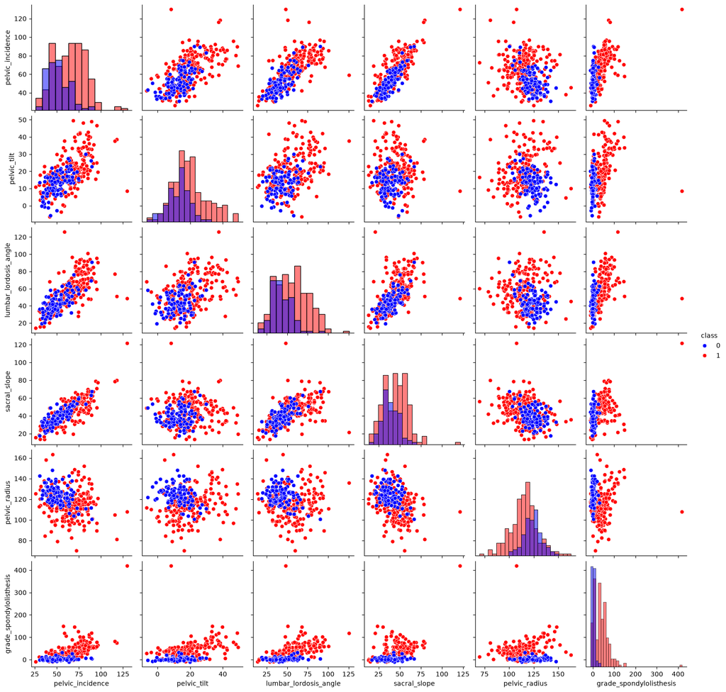

```python
sns.pairplot(
    data,
    vars=independent_variables,
    hue="class",
    palette={0: "blue", 1: "red"},
    diag_kind="hist"
)

plt.show()
```

#### ii. Boxplots

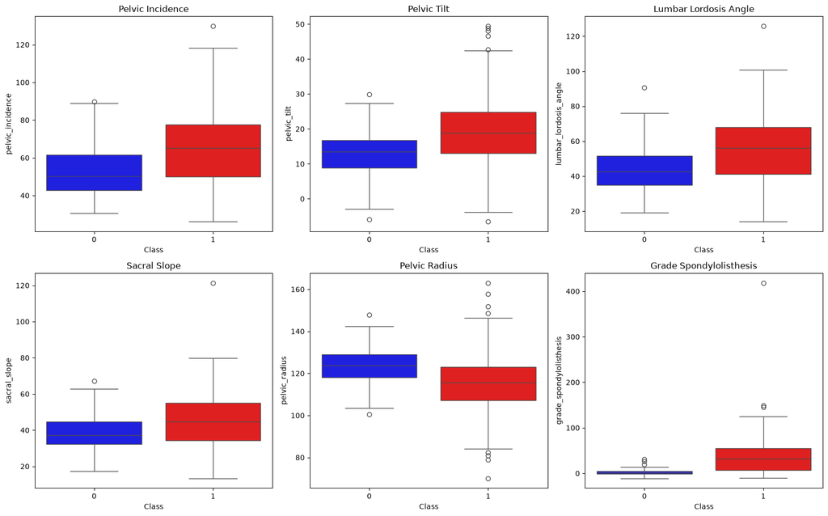

```python
fig, axes = plt.subplots(2, 3, figsize=(16, 10))

for variable, ax in zip(independent_variables, axes.flatten()):
    sns.boxplot(
        data=data,
        x="class",
        y=variable,
        hue="class",
        palette={0: "blue", 1: "red"},
        legend=False,
        ax=ax
    )

    ax.set_title(variable.replace("_", " ").title())
    ax.set_xlabel("Class")

plt.tight_layout()
plt.show()
```

#### iii. Split Data Set

```python
class_0 = data[data["class"] == 0]
class_1 = data[data["class"] == 1]

training_set = pd.concat([
    class_0.iloc[:70],
    class_1.iloc[:140]
]).reset_index(drop=True)
print(training_set)

test_set = pd.concat([
    class_0.iloc[70:],
    class_1.iloc[140:]
]).reset_index(drop=True)
print(test_set)

X_train = training_set[independent_variables]
y_train = training_set["class"]

X_test = test_set[independent_variables]
y_test = test_set["class"]
```

```
     pelvic_incidence  pelvic_tilt  lumbar_lordosis_angle  sacral_slope  \
0               38.51        16.96                  35.11         21.54
1               54.92        18.97                  51.60         35.95
2               44.36         8.95                  46.90         35.42
3               48.32        17.45                  48.00         30.87
4               45.70        10.66                  42.58         35.04
..                ...          ...                    ...           ...
205             77.12        30.35                  77.48         46.77
206             88.02        39.84                  81.77         48.18
207             83.40        34.31                  78.42         49.09
208             72.05        24.70                  79.87         47.35
209             85.10        21.07                  91.73         64.03

     pelvic_radius  grade_spondylolisthesis  class
0           127.63                     7.99      0
```

[output cut: 39 more lines]

### (c) Classification

#### i. Euclidean Metric

```python
knn = KNeighborsClassifier(
    n_neighbors=4,
    metric="euclidean"
)

knn.fit(X_train, y_train)

y_pred = knn.predict(X_test)
```

#### ii. Test Data

##### Test all the data in the test database with *k* nearest neighbors. Take decisions by majority pollin

```python
euclidean_k_values = list(range(208, 0, -3))

euclidean_train_errors = []
euclidean_test_errors = []

for k in euclidean_k_values:
    knn = KNeighborsClassifier(
        n_neighbors=k,
        metric="euclidean"
    )

    knn.fit(X_train, y_train)

    train_predictions = knn.predict(X_train)
    test_predictions = knn.predict(X_test)

    euclidean_train_errors.append(
        1 - accuracy_score(y_train, train_predictions)
    )

    euclidean_test_errors.append(
        1 - accuracy_score(y_test, test_predictions)
    )

best_euclidean_test_error = min(euclidean_test_errors)
best_euclidean_train_error = min(euclidean_train_errors)

best_euclidean_k = min(
    k for k, error in zip(euclidean_k_values, euclidean_test_errors)
    if error == best_euclidean_test_error
)
```

##### Plot train and test errors in terms of k for k ∈ {208,205, . . . ,7,4,1,}(in reverse order)

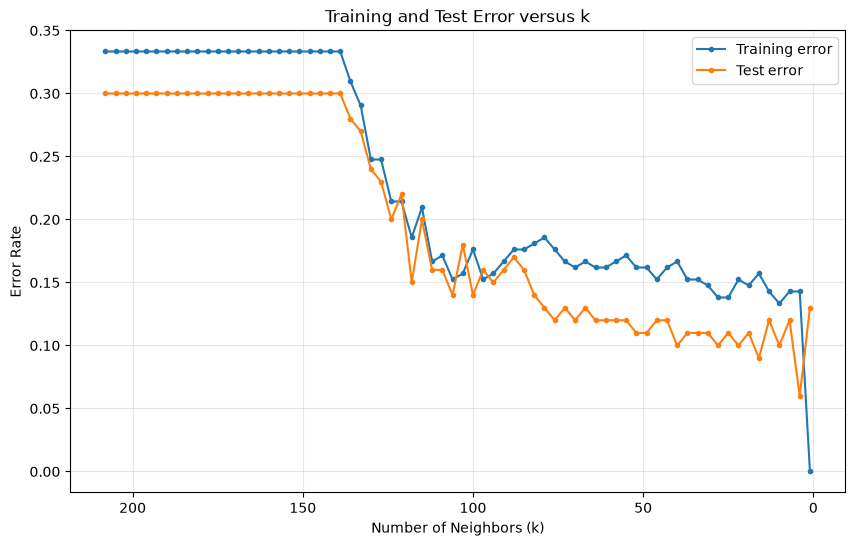

```python
plt.figure(figsize=(10, 6))

plt.plot(
    euclidean_k_values,
    euclidean_train_errors,
    marker="o",
    markersize=3,
    label="Training error"
)

plt.plot(
    euclidean_k_values,
    euclidean_test_errors,
    marker="o",
    markersize=3,
    label="Test error"
)

plt.xlabel("Number of Neighbors (k)")
plt.ylabel("Error Rate")
plt.title("Training and Test Error versus k")
plt.gca().invert_xaxis()
plt.legend()
plt.grid(alpha=0.3)
plt.show()
```

##### Which *k* ∗ is the most suitable *k* among those values?

```python
error_results = pd.DataFrame({
    "k": euclidean_k_values,
    "train_error": euclidean_train_errors,
    "test_error": euclidean_test_errors
})

best_results = error_results[
    error_results["test_error"] == best_euclidean_test_error
]

k_star_euclidean = int(best_results["k"].min())

print("Best k:", k_star_euclidean)
print("Minimum test error:", best_euclidean_test_error)

best_results.sort_values("k")
```

```
Best k: 4
Minimum test error: 0.06000000000000005
```

|  | k | train_error | test_error |
| --- | --- | --- | --- |
| 68 | 4 | 0.142857 | 0.06 |

##### Display Confusion Matrix, true positive rate, true negative rate, precision,and F1-score when k = k∗

```python
best_knn = KNeighborsClassifier(
    n_neighbors=k_star_euclidean,
    metric="euclidean"
)

best_knn.fit(X_train, y_train)
y_pred = best_knn.predict(X_test)

cm = confusion_matrix(y_test, y_pred)

tn, fp, fn, tp = cm.ravel()

true_positive_rate = tp / (tp + fn)
true_negative_rate = tn / (tn + fp)
precision = precision_score(y_test, y_pred, pos_label=1)
f1 = f1_score(y_test, y_pred, pos_label=1)

print(f"True positive rate: {true_positive_rate:.4f}")
print(f"True negative rate: {true_negative_rate:.4f}")
print(f"Precision:          {precision:.4f}")
print(f"F1-score:           {f1:.4f}")
```

```
True positive rate: 0.9857
True negative rate: 0.8333
Precision:          0.9324
F1-score:           0.9583
```

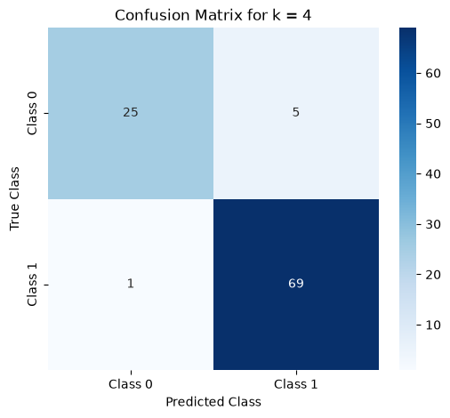

```python
plt.figure(figsize=(6, 5))

sns.heatmap(
    cm,
    annot=True,
    fmt="d",
    cmap="Blues",
    xticklabels=["Class 0", "Class 1"],
    yticklabels=["Class 0", "Class 1"]
)

plt.xlabel("Predicted Class")
plt.ylabel("True Class")
plt.title(f"Confusion Matrix for k = {k_star_euclidean}")
plt.show()
```

#### iii. Learning Curve

##### Re-run classifer on subsets of the data of various sizes from 10-210 in increments of 10

```python
N_values = list(range(10, 211, 10))

best_test_errors = []
best_k_values = []

training_class_0 = training_set[training_set["class"] == 0]
training_class_1 = training_set[training_set["class"] == 1]

for N in N_values:
    number_class_0 = N // 3
    number_class_1 = N - number_class_0

    subset = pd.concat([
        training_class_0.iloc[:number_class_0],
        training_class_1.iloc[:number_class_1]
    ])

    X_train_subset = subset[independent_variables]
    y_train_subset = subset["class"]

    # For N=200, this produces 1, 6, 11, ..., 196
    candidate_k_values = list(range(1, N, 5))

    errors_for_N = []

    for k in candidate_k_values:
        knn = KNeighborsClassifier(
            n_neighbors=k,
            metric="euclidean"
        )

        knn.fit(X_train_subset, y_train_subset)
        predictions = knn.predict(X_test)

        test_error = 1 - accuracy_score(y_test, predictions)
        errors_for_N.append(test_error)

    minimum_error = min(errors_for_N)

    # Select the smallest k in case of a tie
    optimal_k = min(
        k for k, error in zip(candidate_k_values, errors_for_N)
        if error == minimum_error
    )

    best_test_errors.append(minimum_error)
    best_k_values.append(optimal_k)
```

```python
learning_curve_results = pd.DataFrame({
    "training_size": N_values,
    "optimal_k": best_k_values,
    "best_test_error": best_test_errors
})

learning_curve_results
```

|  | training_size | optimal_k | best_test_error |
| --- | --- | --- | --- |
| 0 | 10 | 1 | 0.25 |
| 1 | 20 | 6 | 0.20 |
| 2 | 30 | 1 | 0.22 |
| 3 | 40 | 11 | 0.25 |
| 4 | 50 | 26 | 0.30 |
| 5 | 60 | 21 | 0.29 |
| 6 | 70 | 26 | 0.29 |
| 7 | 80 | 31 | 0.29 |
| 8 | 90 | 41 | 0.29 |
| 9 | 100 | 6 | 0.25 |
| 10 | 110 | 6 | 0.22 |
| 11 | 120 | 16 | 0.17 |
| 12 | 130 | 16 | 0.16 |
| 13 | 140 | 16 | 0.15 |
| 14 | 150 | 16 | 0.13 |
| 15 | 160 | 6 | 0.13 |
| 16 | 170 | 6 | 0.13 |
| 17 | 180 | 6 | 0.10 |
| 18 | 190 | 6 | 0.09 |
| 19 | 200 | 6 | 0.09 |
| 20 | 210 | 6 | 0.08 |

##### Plot the Learning Curve

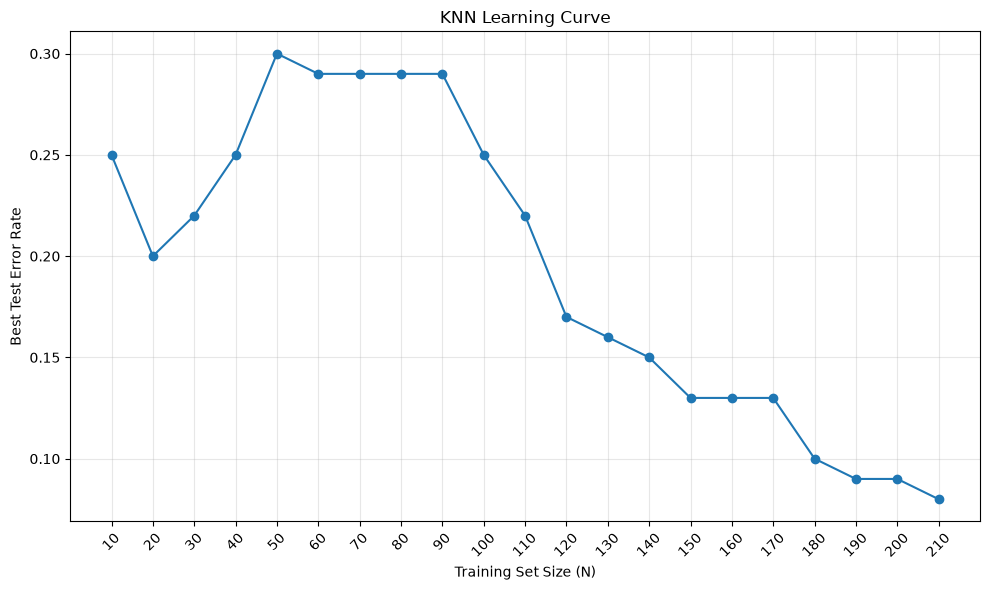

```python
plt.figure(figsize=(10, 6))

plt.plot(
    N_values,
    best_test_errors,
    marker="o"
)

plt.xlabel("Training Set Size (N)")
plt.ylabel("Best Test Error Rate")
plt.title("KNN Learning Curve")
plt.xticks(N_values, rotation=45)
plt.grid(alpha=0.3)
plt.tight_layout()
plt.show()
```

### (d) Other Metrics

Replace the Euclidean metric with the following metrics and test them. Summarize the test errors (i.e., when k=k∗ ) in a table. Use all of your training data and select the best k when {1,6,11, . . . ,196}

```python
#initiate k values
k_values = list(range(1, 197, 5))
print(k_values)
```

```
[1, 6, 11, 16, 21, 26, 31, 36, 41, 46, 51, 56, 61, 66, 71, 76, 81, 86, 91, 96, 101, 106, 111, 116, 121, 126, 131, 136, 141, 146, 151, 156, 161, 166, 171, 176, 181, 186, 191, 196]
```

#### i. Minkowski Distance.

##### a. Manhattan Distance with p = 1.

```python
manhattan_train_errors = []
manhattan_test_errors = []

for k in k_values:
    knn = KNeighborsClassifier(
        n_neighbors=k,
        metric="manhattan"
    )

    knn.fit(X_train, y_train)

    train_predictions = knn.predict(X_train)
    test_predictions = knn.predict(X_test)

    manhattan_train_errors.append(
        1 - accuracy_score(y_train, train_predictions)
    )

    manhattan_test_errors.append(
        1 - accuracy_score(y_test, test_predictions)
    )

best_manhattan_test_error = min(manhattan_test_errors)
best_manhattan_train_error = min(manhattan_train_errors)

best_manhattan_k = min(
    k for k, error in zip(k_values, manhattan_test_errors)
    if error == best_manhattan_test_error
)

#store restules in data frame
manhattan_results = pd.DataFrame({
    "k": k_values,
    "training_error": manhattan_train_errors,
    "test_error": manhattan_test_errors
})

manhattan_results
```

|  | k | training_error | test_error |
| --- | --- | --- | --- |
| 0 | 1 | 0.000000 | 0.12 |
| 1 | 6 | 0.138095 | 0.11 |
| 2 | 11 | 0.142857 | 0.11 |
| 3 | 16 | 0.133333 | 0.12 |
| 4 | 21 | 0.147619 | 0.12 |
| 5 | 26 | 0.166667 | 0.11 |
| 6 | 31 | 0.166667 | 0.12 |
| 7 | 36 | 0.161905 | 0.13 |
| 8 | 41 | 0.166667 | 0.13 |
| 9 | 46 | 0.171429 | 0.13 |
| 10 | 51 | 0.171429 | 0.14 |
| 11 | 56 | 0.185714 | 0.13 |
| 12 | 61 | 0.176190 | 0.15 |
| 13 | 66 | 0.180952 | 0.15 |
| 14 | 71 | 0.176190 | 0.14 |
| 15 | 76 | 0.180952 | 0.14 |
| 16 | 81 | 0.166667 | 0.16 |
| 17 | 86 | 0.152381 | 0.15 |
| 18 | 91 | 0.180952 | 0.20 |
| 19 | 96 | 0.176190 | 0.20 |
| 20 | 101 | 0.200000 | 0.22 |
| 21 | 106 | 0.204762 | 0.21 |
| 22 | 111 | 0.219048 | 0.23 |
| 23 | 116 | 0.228571 | 0.21 |
| 24 | 121 | 0.242857 | 0.22 |
| 25 | 126 | 0.261905 | 0.24 |
| 26 | 131 | 0.304762 | 0.28 |
| 27 | 136 | 0.323810 | 0.28 |
| 28 | 141 | 0.333333 | 0.30 |
| 29 | 146 | 0.333333 | 0.30 |
| 30 | 151 | 0.333333 | 0.30 |
| 31 | 156 | 0.333333 | 0.30 |
| 32 | 161 | 0.333333 | 0.30 |
| 33 | 166 | 0.333333 | 0.30 |
| 34 | 171 | 0.333333 | 0.30 |
| 35 | 176 | 0.333333 | 0.30 |
| 36 | 181 | 0.333333 | 0.30 |
| 37 | 186 | 0.333333 | 0.30 |
| 38 | 191 | 0.333333 | 0.30 |
| 39 | 196 | 0.333333 | 0.30 |

```python
print("Best Manhattan k:", best_manhattan_k)
print("Best Manhattan test error:", best_manhattan_test_error)
```

```
Best Manhattan k: 6
Best Manhattan test error: 0.10999999999999999
```

##### b. With log10(p) in {0.1, 0.2, 0.3, ... ,1}.

```python
log10_p_values = np.arange(0.1, 1.01, 0.1)

minkowski_train_errors = []
minkowski_test_errors = []

for log10_p in log10_p_values:
    p = 10 ** log10_p

    knn = KNeighborsClassifier(
        n_neighbors=best_manhattan_k,
        metric="minkowski",
        p=p
    )

    knn.fit(X_train, y_train)

    train_predictions = knn.predict(X_train)
    test_predictions = knn.predict(X_test)

    minkowski_train_errors.append(
        1 - accuracy_score(y_train, train_predictions)
    )

    minkowski_test_errors.append(
        1 - accuracy_score(y_test, test_predictions)
    )

best_minkowski_test_error = min(minkowski_test_errors)
best_minkowski_train_error = min(minkowski_train_errors)

best_log10_p_minkowski = min(
    log_p
    for log_p, error in zip(log10_p_values, minkowski_test_errors)
    if error == best_minkowski_test_error
)

minkowski_results = pd.DataFrame({
    "log10(p)": np.round(log10_p_values, 1),
    "p": 10 ** log10_p_values,
    "train_error": minkowski_train_errors,
    "test_error": minkowski_test_errors
})

minkowski_results
```

|  | log10(p) | p | train_error | test_error |
| --- | --- | --- | --- | --- |
| 0 | 0.1 | 1.258925 | 0.138095 | 0.09 |
| 1 | 0.2 | 1.584893 | 0.147619 | 0.09 |
| 2 | 0.3 | 1.995262 | 0.152381 | 0.08 |
| 3 | 0.4 | 2.511886 | 0.152381 | 0.08 |
| 4 | 0.5 | 3.162278 | 0.147619 | 0.08 |
| 5 | 0.6 | 3.981072 | 0.152381 | 0.06 |
| 6 | 0.7 | 5.011872 | 0.152381 | 0.07 |
| 7 | 0.8 | 6.309573 | 0.147619 | 0.08 |
| 8 | 0.9 | 7.943282 | 0.147619 | 0.09 |
| 9 | 1.0 | 10.000000 | 0.133333 | 0.09 |

```python
best_p = 10 ** best_log10_p_minkowski

print("Best log10(p):", round(best_log10_p_minkowski, 1))
print("Best p:", best_p)
print("Best Minkowski test error:", best_minkowski_test_error)
```

```
Best log10(p): 0.6
Best p: 3.981071705534973
Best Minkowski test error: 0.06000000000000005
```

##### C. Chebyshev Distance With p -> infinity.

```python
chebyshev_train_errors = []
chebyshev_test_errors = []

for k in k_values:
    knn = KNeighborsClassifier(
        n_neighbors=k,
        metric="chebyshev"
    )

    knn.fit(X_train, y_train)

    train_predictions = knn.predict(X_train)
    test_predictions = knn.predict(X_test)

    chebyshev_train_errors.append(
        1 - accuracy_score(y_train, train_predictions)
    )

    chebyshev_test_errors.append(
        1 - accuracy_score(y_test, test_predictions)
    )

best_chebyshev_test_error = min(chebyshev_test_errors)
best_chebyshev_train_error = min(chebyshev_train_errors)

best_chebyshev_k = min(
    k for k, error in zip(k_values, chebyshev_test_errors)
    if error == best_chebyshev_test_error
)

chebyshev_results = pd.DataFrame({
    "k": k_values,
    "train_error": chebyshev_train_errors,
    "test_error": chebyshev_test_errors
})

chebyshev_results
```

|  | k | train_error | test_error |
| --- | --- | --- | --- |
| 0 | 1 | 0.000000 | 0.13 |
| 1 | 6 | 0.152381 | 0.10 |
| 2 | 11 | 0.152381 | 0.12 |
| 3 | 16 | 0.152381 | 0.08 |
| 4 | 21 | 0.133333 | 0.11 |
| 5 | 26 | 0.157143 | 0.12 |
| 6 | 31 | 0.142857 | 0.12 |
| 7 | 36 | 0.152381 | 0.10 |
| 8 | 41 | 0.142857 | 0.13 |
| 9 | 46 | 0.161905 | 0.12 |
| 10 | 51 | 0.166667 | 0.12 |
| 11 | 56 | 0.166667 | 0.12 |
| 12 | 61 | 0.171429 | 0.14 |
| 13 | 66 | 0.161905 | 0.13 |
| 14 | 71 | 0.180952 | 0.14 |
| 15 | 76 | 0.176190 | 0.11 |
| 16 | 81 | 0.171429 | 0.14 |
| 17 | 86 | 0.171429 | 0.12 |
| 18 | 91 | 0.157143 | 0.15 |
| 19 | 96 | 0.161905 | 0.14 |
| 20 | 101 | 0.171429 | 0.19 |
| 21 | 106 | 0.176190 | 0.18 |
| 22 | 111 | 0.180952 | 0.18 |
| 23 | 116 | 0.176190 | 0.19 |
| 24 | 121 | 0.209524 | 0.21 |
| 25 | 126 | 0.223810 | 0.21 |
| 26 | 131 | 0.247619 | 0.25 |
| 27 | 136 | 0.319048 | 0.28 |
| 28 | 141 | 0.333333 | 0.30 |
| 29 | 146 | 0.333333 | 0.30 |
| 30 | 151 | 0.333333 | 0.30 |
| 31 | 156 | 0.333333 | 0.30 |
| 32 | 161 | 0.333333 | 0.30 |
| 33 | 166 | 0.333333 | 0.30 |
| 34 | 171 | 0.333333 | 0.30 |
| 35 | 176 | 0.333333 | 0.30 |
| 36 | 181 | 0.333333 | 0.30 |
| 37 | 186 | 0.333333 | 0.30 |
| 38 | 191 | 0.333333 | 0.30 |
| 39 | 196 | 0.333333 | 0.30 |

```python
print("Best Chebyshev k:", best_chebyshev_k)
print("Best Chebyshev test error:", best_chebyshev_test_error)
```

```
Best Chebyshev k: 16
Best Chebyshev test error: 0.07999999999999996
```

#### ii. Mahalanobis Distance.

```python
X_train_array = X_train.to_numpy(dtype=float)
X_test_array = X_test.to_numpy(dtype=float)

covariance_matrix = np.cov(X_train_array, rowvar=False)
inverse_covariance_matrix = np.linalg.pinv(covariance_matrix)

mahalanobis_train_errors = []
mahalanobis_test_errors = []

for k in k_values:
    knn = KNeighborsClassifier(
        n_neighbors=k,
        metric="mahalanobis",
        metric_params={"VI": inverse_covariance_matrix},
        algorithm="brute"
    )

    knn.fit(X_train_array, y_train)

    train_predictions = knn.predict(X_train_array)
    test_predictions = knn.predict(X_test_array)

    mahalanobis_train_errors.append(
        1 - accuracy_score(y_train, train_predictions)
    )

    mahalanobis_test_errors.append(
        1 - accuracy_score(y_test, test_predictions)
    )

best_mahalanobis_test_error = min(mahalanobis_test_errors)
best_mahalanobis_train_error = min(mahalanobis_train_errors)

best_mahalanobis_k = min(
    k for k, error in zip(k_values, mahalanobis_test_errors)
    if error == best_mahalanobis_test_error
)

mahalanobis_results = pd.DataFrame({
    "k": k_values,
    "train_error": mahalanobis_train_errors,
    "test_error": mahalanobis_test_errors
})

mahalanobis_results
```

|  | k | train_error | test_error |
| --- | --- | --- | --- |
| 0 | 1 | 0.000000 | 0.17 |
| 1 | 6 | 0.119048 | 0.17 |
| 2 | 11 | 0.185714 | 0.20 |
| 3 | 16 | 0.176190 | 0.20 |
| 4 | 21 | 0.176190 | 0.21 |
| 5 | 26 | 0.185714 | 0.20 |
| 6 | 31 | 0.180952 | 0.23 |
| 7 | 36 | 0.180952 | 0.21 |
| 8 | 41 | 0.185714 | 0.24 |
| 9 | 46 | 0.185714 | 0.24 |
| 10 | 51 | 0.190476 | 0.24 |
| 11 | 56 | 0.190476 | 0.26 |
| 12 | 61 | 0.204762 | 0.25 |
| 13 | 66 | 0.195238 | 0.27 |
| 14 | 71 | 0.219048 | 0.26 |
| 15 | 76 | 0.214286 | 0.25 |
| 16 | 81 | 0.238095 | 0.24 |
| 17 | 86 | 0.233333 | 0.26 |
| 18 | 91 | 0.252381 | 0.26 |
| 19 | 96 | 0.242857 | 0.26 |
| 20 | 101 | 0.285714 | 0.28 |
| 21 | 106 | 0.300000 | 0.28 |
| 22 | 111 | 0.295238 | 0.31 |
| 23 | 116 | 0.323810 | 0.29 |
| 24 | 121 | 0.328571 | 0.30 |
| 25 | 126 | 0.328571 | 0.30 |
| 26 | 131 | 0.333333 | 0.30 |
| 27 | 136 | 0.333333 | 0.30 |
| 28 | 141 | 0.333333 | 0.30 |
| 29 | 146 | 0.333333 | 0.30 |
| 30 | 151 | 0.333333 | 0.30 |
| 31 | 156 | 0.333333 | 0.30 |
| 32 | 161 | 0.333333 | 0.30 |
| 33 | 166 | 0.333333 | 0.30 |
| 34 | 171 | 0.333333 | 0.30 |
| 35 | 176 | 0.333333 | 0.30 |
| 36 | 181 | 0.333333 | 0.30 |
| 37 | 186 | 0.333333 | 0.30 |
| 38 | 191 | 0.333333 | 0.30 |
| 39 | 196 | 0.333333 | 0.30 |

```python
print("Best Mahalanobis k:", best_mahalanobis_k)
print("Best Mahalanobis test error:", best_mahalanobis_test_error)
```

```
Best Mahalanobis k: 1
Best Mahalanobis test error: 0.17000000000000004
```

```python
distance_summary_table = pd.DataFrame({

    "Distance Metric": [
        "Euclidean",
        "Manhattan",
        "Minkowski",
        "Chebyshev",
        "Mahalanobis"
    ],

    "Best k (or log(p) for Minkowski)": [
        k_star_euclidean,
        best_manhattan_k,
        best_log10_p_minkowski,
        best_chebyshev_k,
        best_mahalanobis_k
    ],

    "Best Test Error": [
            best_euclidean_test_error,
            best_manhattan_test_error,
            best_minkowski_test_error,
            best_chebyshev_test_error,
            best_mahalanobis_test_error
        ]
})

distance_summary_table["Best Test Error"] = distance_summary_table["Best Test Error"].round(4)

distance_summary_table
```

|  | Distance Metric | Best k (or log(p) for Minkowski) | Best Test Error |
| --- | --- | --- | --- |
| 0 | Euclidean | 4.0 | 0.06 |
| 1 | Manhattan | 6.0 | 0.11 |
| 2 | Minkowski | 0.6 | 0.06 |
| 3 | Chebyshev | 16.0 | 0.08 |
| 4 | Mahalanobis | 1.0 | 0.17 |

### (e) Weighted Decision

Notes: purpose of weighting the distance is to prevent relatively distant neighbors from having the same influence as nearby observations, hence the inverse proportion detail in the instructions.

#### Weighted Euclidean Distance

```python
weighted_euclidean_train_errors = []
weighted_euclidean_test_errors = []

for k in k_values:
    knn = KNeighborsClassifier(
        n_neighbors=k,
        metric="euclidean",
        weights="distance"
    )

    knn.fit(X_train, y_train)

    train_predictions = knn.predict(X_train)
    test_predictions = knn.predict(X_test)

    weighted_euclidean_train_errors.append(
        1 - accuracy_score(y_train, train_predictions)
    )

    weighted_euclidean_test_errors.append(
        1 - accuracy_score(y_test, test_predictions)
    )

best_weighted_euclidean_test_error = min(weighted_euclidean_test_errors)
best_weighted_euclidean_train_error = min(weighted_euclidean_train_errors)

best_weighted_euclidean_k = min(
    k for k, error in zip(k_values, weighted_euclidean_test_errors)
    if error == best_weighted_euclidean_test_error
)

print("Best weighted Euclidean k:", best_weighted_euclidean_k)
print("Best weighted Euclidean test error:", best_weighted_euclidean_test_error)
```

```
Best weighted Euclidean k: 6
Best weighted Euclidean test error: 0.09999999999999998
```

#### Weighted Manhattan Distance

```python
weighted_manhattan_train_errors = []
weighted_manhattan_test_errors = []

for k in k_values:
    knn = KNeighborsClassifier(
        n_neighbors=k,
        metric="manhattan",
        weights="distance"
    )

    knn.fit(X_train, y_train)

    train_predictions = knn.predict(X_train)
    test_predictions = knn.predict(X_test)

    weighted_manhattan_train_errors.append(
        1 - accuracy_score(y_train, train_predictions)
    )

    weighted_manhattan_test_errors.append(
        1 - accuracy_score(y_test, test_predictions)
    )

best_weighted_manhattan_test_error = min(weighted_manhattan_test_errors)
best_weighted_manhattan_train_error = min(weighted_manhattan_train_errors)

best_weighted_manhattan_k = min(
    k for k, error in zip(k_values, weighted_manhattan_test_errors)
    if error == best_weighted_manhattan_test_error
)

print("Best weighted Manhattan k:", best_weighted_manhattan_k)
print("Best weighted Manhattan test error:", best_weighted_manhattan_test_error)
```

```
Best weighted Manhattan k: 26
Best weighted Manhattan test error: 0.09999999999999998
```

#### Weighted Chebysev's Distance

```python
weighted_chebyshev_train_errors = []
weighted_chebyshev_test_errors = []

for k in k_values:
    knn = KNeighborsClassifier(
        n_neighbors=k,
        metric="chebyshev",
        weights="distance"
    )

    knn.fit(X_train, y_train)

    train_predictions = knn.predict(X_train)
    test_predictions = knn.predict(X_test)

    weighted_chebyshev_train_errors.append(
        1 - accuracy_score(y_train, train_predictions)
    )

    weighted_chebyshev_test_errors.append(
        1 - accuracy_score(y_test, test_predictions)
    )

best_weighted_chebyshev_test_error = min(weighted_chebyshev_test_errors)
best_weighted_chebyshev_train_error = min(weighted_chebyshev_train_errors)

best_weighted_chebyshev_k = min(
    k for k, error in zip(k_values, weighted_chebyshev_test_errors)
    if error == best_weighted_chebyshev_test_error
)

print("Best weighted Chebyshev k:", best_weighted_chebyshev_k)
print("Best weighted Chebyshev test error:", best_weighted_chebyshev_test_error)
```

```
Best weighted Chebyshev k: 16
Best weighted Chebyshev test error: 0.10999999999999999
```

### (f) Training Error Rate

```python
all_train_errors = pd.DataFrame({
    "Voting Method": [
        "Unweighted",
        "Unweighted",
        "Unweighted",
        "Unweighted",
        "Unweighted",
        "Distance-weighted",
        "Distance-weighted",
        "Distance-weighted"
    ],

    "Distance Metric": [
        "Euclidean",
        "Manhattan",
        "Minkowski",
        "Chebyshev",
        "Mahalanobis",
        "Euclidean",
        "Manhattan",
        "Chebyshev"
    ],

    "Best Train Error": [
        best_euclidean_train_error,
        best_manhattan_train_error,
        best_minkowski_train_error,
        best_chebyshev_train_error,
        best_mahalanobis_train_error,
        best_weighted_euclidean_train_error,
        best_weighted_manhattan_train_error,
        best_weighted_chebyshev_train_error
    ]
})

all_train_errors["Best Train Error"] = all_train_errors["Best Train Error"].round(4)

all_train_errors
```

|  | Voting Method | Distance Metric | Best Train Error |
| --- | --- | --- | --- |
| 0 | Unweighted | Euclidean | 0.0000 |
| 1 | Unweighted | Manhattan | 0.0000 |
| 2 | Unweighted | Minkowski | 0.1333 |
| 3 | Unweighted | Chebyshev | 0.0000 |
| 4 | Unweighted | Mahalanobis | 0.0000 |
| 5 | Distance-weighted | Euclidean | 0.0000 |
| 6 | Distance-weighted | Manhattan | 0.0000 |
| 7 | Distance-weighted | Chebyshev | 0.0000 |

The lowest training error achieved in this assignment was 0.00, indicating perfect classification of the training data. This occurred because most methods included (k=1), meaning that each training observation was its own nearest neighbor and was therefore classified correctly. The only method with a nonzero minimum training error was unweighted Minkowski distance. This method used the optimal (k) found for Manhattan distance, which was (k*=6), rather than (k=1). Because each prediction used multiple neighbors, some training error was expected.

### (f) Testing Error (Summary)

```python
all_test_errors = pd.DataFrame({
    "Voting Method": [
        "Unweighted",
        "Unweighted",
        "Unweighted",
        "Unweighted",
        "Unweighted",
        "Distance-weighted",
        "Distance-weighted",
        "Distance-weighted"
    ],

    "Distance Metric": [
        "Euclidean",
        "Manhattan",
        "Minkowski",
        "Chebyshev",
        "Mahalanobis",
        "Euclidean",
        "Manhattan",
        "Chebyshev"
    ],

    "Best Test Error": [
        best_euclidean_test_error,
        best_manhattan_test_error,
        best_minkowski_test_error,
        best_chebyshev_test_error,
        best_mahalanobis_test_error,
        best_weighted_euclidean_test_error,
        best_weighted_manhattan_test_error,
        best_weighted_chebyshev_test_error
    ]
})

all_test_errors["Best Test Error"] = all_test_errors["Best Test Error"].round(4)

all_test_errors
```

|  | Voting Method | Distance Metric | Best Test Error |
| --- | --- | --- | --- |
| 0 | Unweighted | Euclidean | 0.06 |
| 1 | Unweighted | Manhattan | 0.11 |
| 2 | Unweighted | Minkowski | 0.06 |
| 3 | Unweighted | Chebyshev | 0.08 |
| 4 | Unweighted | Mahalanobis | 0.17 |
| 5 | Distance-weighted | Euclidean | 0.10 |
| 6 | Distance-weighted | Manhattan | 0.10 |
| 7 | Distance-weighted | Chebyshev | 0.11 |

**Answer**

In summary, although most methods achieved a training error of 0.00, this did not necessarily make them the best classifiers for unseen data. In fact, unweighted Minkowski KNN had the highest minimum training error but tied for the lowest test error. This demonstrates the important distinction between the two measures: training error reflects how well a model fits the data on which it was trained, whereas test error reflects how well the model generalizes to unseen data.